# Chess Rating Dynamics and the Limits of Individual Improvement Inference

Author

George Ellis

## 1 Overview

This project investigates whether improvement in chess skill can be reliably detected from rating data alone.

We begin with a simple Bayesian before/after comparison, then progressively introduce:

- opponent matching effects
- latent skill dynamics
- hierarchical modeling across players

The final result is a mean-reverting latent skill model with opponent-strength adjustment, applied to real Lichess data.

## 2 Motivation

Online platforms such as Lichess match players of similar strength. This creates a fundamental problem:

- win rates may remain stable even if skill improves
- rating trajectories are noisy and mean-reverting
- opponent strength confounds interpretation

Therefore, detecting improvement requires:

- modeling latent skill
- accounting for opponent strength
- separating signal from noise

## 3 Data

We analyze a cohort of players who:

- played at least **50 games in at least 2 years**
- were active between **2022–2025**

Data are aggregated to:

- monthly average player Elo
- monthly average opponent Elo
- number of games per month

## 4 Model

We model latent skill ( s_{i,t} ) as:

$$s_{i,t} = s_{i,t-1} + \kappa(\mu_{i,t} - s_{i,t-1}) + \varepsilon_{i,t}$$

where:

- `kappa` is the mean-reversion parameter
- `epsilon_{i,t} ~ Normal(0, sigma_state)` is the state innovation

The long-run target evolves as:

$$\mu_{i,t} = \alpha_i + \beta_i t$$

with:

- `alpha_i` = player-specific baseline
- `beta_i` = player-specific trend

## 5 Opponent Strength Adjustment

Observed ratings are influenced by opponent strength.

We model:

$$y_{i,t} \sim \mathcal{N}(s_{i,t} + \gamma (O_{i,t} - \bar{O}), \sigma_{obs} / \sqrt{n_{i,t}})$$

## 6 Results

### 6.1 Parameter Estimates

```python
import pandas as pd
summary = pd.read_csv("multi_v24_trend_opp_fixed_summary.csv")
summary
```

|  | Unnamed: 0 | mean | sd | hdi_3% | hdi_97% | mcse_mean | mcse_sd | ess_bulk | ess_tail | r_hat |
| --- | --- | --- | --- | --- | --- | --- | --- | --- | --- | --- |
| 0 | alpha_pop | 1745.2367 | 5.9174 | 1735.1033 | 1756.2669 | 2.2477 | 0.6588 | 7.1316 | 32.8567 | 1.5320 |
| 1 | sigma_alpha | 23.4903 | 32.5351 | 0.1081 | 81.1834 | 16.1242 | 8.6908 | 4.9336 | 23.1578 | 2.3730 |
| 2 | beta_pop | -4.9332 | 7.0644 | -15.6312 | 6.3813 | 2.9108 | 0.8885 | 6.7483 | 27.2083 | 1.6102 |
| 3 | sigma_beta | 18.6400 | 14.6086 | 0.1983 | 40.3113 | 6.9357 | 2.2267 | 4.8338 | 16.9452 | 2.5359 |
| 4 | kappa | 0.0703 | 0.0893 | 0.0140 | 0.2375 | 0.0442 | 0.0258 | 6.5721 | 39.0859 | 1.6285 |
| 5 | sigma_state | 15.0881 | 1.4801 | 13.4043 | 17.9608 | 0.7007 | 0.3799 | 7.1572 | 37.3625 | 1.5766 |
| 6 | sigma_obs | 151.8326 | 9.6792 | 132.6374 | 162.9841 | 4.5642 | 2.4815 | 7.0778 | 42.9010 | 1.5642 |
| 7 | gamma | 0.6670 | 0.0125 | 0.6417 | 0.6871 | 0.0049 | 0.0022 | 7.4636 | 30.8695 | 1.5033 |

### 6.2 Distribution of Player Trends

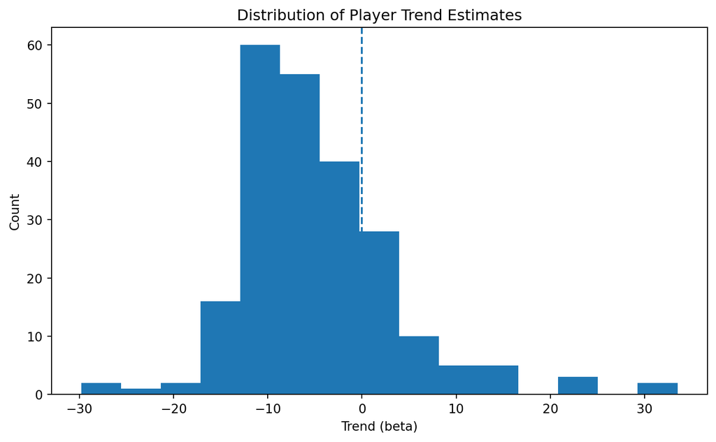

```python
import pandas as pd
import matplotlib.pyplot as plt

df = pd.read_csv("multi_v24_player_trends_opp_fixed.csv")

plt.figure(figsize=(8, 5))
plt.hist(df["beta_mean"], bins=15)
plt.axvline(0, linestyle="--")
plt.title("Distribution of Player Trend Estimates")
plt.xlabel("Trend (beta)")
plt.ylabel("Count")
plt.tight_layout()
plt.show()
```

### 6.3 Strongest Evidence of Change

```python
df_sorted = df.sort_values("evidence_strength", ascending=False)
df_sorted.head(10)
```

|  | player_id | username | alpha_mean | alpha_lwr | alpha_upr | beta_mean | beta_lwr | beta_upr | prob_beta_positive | elo_change_mean | elo_change_lwr | elo_change_upr | trajectory_class | evidence_strength |
| --- | --- | --- | --- | --- | --- | --- | --- | --- | --- | --- | --- | --- | --- | --- |
| 0 | 147 | mismotor | 1792.055695 | 1735.085642 | 1954.251816 | -22.966269 | -87.068097 | 18.843669 | 0.10625 | -45.932537 | -174.136195 | 37.687338 | stable/uncertain | 0.39375 |
| 1 | 133 | manova-jeu | 1757.498396 | 1733.796572 | 1814.569866 | -29.804960 | -105.715794 | 17.481012 | 0.11050 | -59.609919 | -211.431589 | 34.962025 | stable/uncertain | 0.38950 |
| 2 | 159 | ninastorozhenko72 | 1754.774415 | 1733.585088 | 1804.491351 | -29.090279 | -108.967012 | 21.093442 | 0.12075 | -58.180557 | -217.934024 | 42.186885 | stable/uncertain | 0.37925 |
| 3 | 173 | reflection1502 | 1761.859305 | 1733.887908 | 1824.991913 | -19.569013 | -67.719318 | 22.679990 | 0.12725 | -39.138025 | -135.438636 | 45.359981 | stable/uncertain | 0.37275 |
| 4 | 180 | safiri | 1771.369933 | 1734.551398 | 1870.607478 | -18.484142 | -69.734704 | 18.823298 | 0.12900 | -36.968284 | -139.469409 | 37.646596 | stable/uncertain | 0.37100 |
| 5 | 111 | karimkot | 1756.282578 | 1734.541792 | 1811.100884 | -15.425768 | -60.405638 | 24.316236 | 0.15250 | -30.851536 | -120.811276 | 48.632472 | stable/uncertain | 0.34750 |
| 6 | 150 | moslem403019 | 1754.951918 | 1734.201666 | 1800.505818 | -14.829868 | -58.211284 | 26.946336 | 0.15250 | -29.659735 | -116.422567 | 53.892672 | stable/uncertain | 0.34750 |
| 7 | 83 | gorgojokiller | 1755.131781 | 1734.028070 | 1800.811644 | -15.068181 | -58.161724 | 23.626524 | 0.16075 | -30.136362 | -116.323447 | 47.253047 | stable/uncertain | 0.33925 |
| 8 | 157 | nemanjabogut1983 | 1746.971893 | 1727.882507 | 1781.455331 | -15.243130 | -62.524147 | 27.867511 | 0.16350 | -30.486260 | -125.048294 | 55.735021 | stable/uncertain | 0.33650 |
| 9 | 179 | s4cr3d | 1778.684953 | 1734.995680 | 1892.726515 | -15.688150 | -70.850299 | 20.567783 | 0.16350 | -31.376299 | -141.700599 | 41.135566 | stable/uncertain | 0.33650 |

### 6.4 Example Player Trajectories

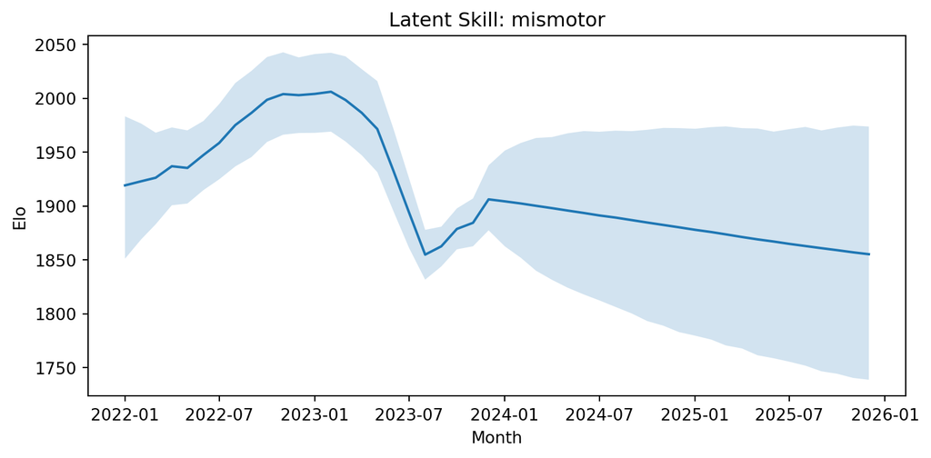

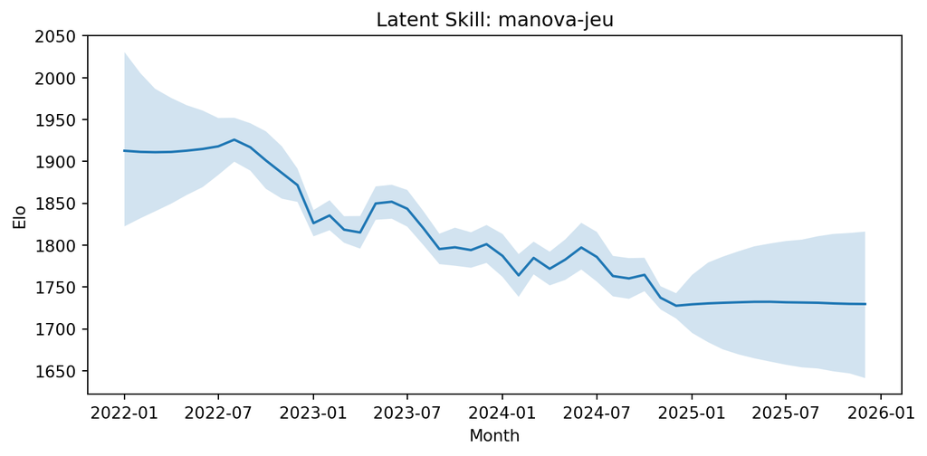

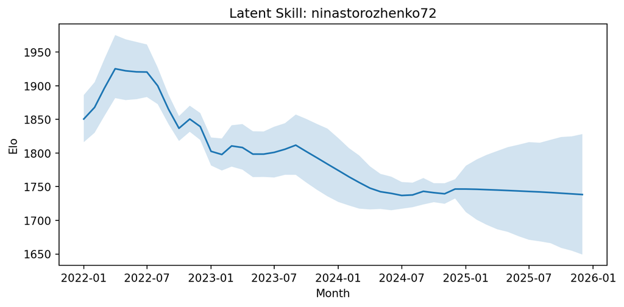

```python
skill_df = pd.read_csv("multi_v24_skill_paths_opp_fixed.csv")
skill_df["month"] = pd.to_datetime(skill_df["month"])

top_players = df_sorted.head(3)["username"].tolist()

for p in top_players:
    sub = skill_df[skill_df["username"] == p].sort_values("month")
    plt.figure(figsize=(8, 4))
    plt.plot(sub["month"], sub["skill_mean"])
    plt.fill_between(sub["month"], sub["skill_lwr"], sub["skill_upr"], alpha=0.2)
    plt.title(f"Latent Skill: {p}")
    plt.xlabel("Month")
    plt.ylabel("Elo")
    plt.tight_layout()
    plt.show()
```

## 8 Interpretation

Even with a sophisticated model:

- latent skill is noisy
- ratings are heavily influenced by opponent strength
- individual improvement is difficult to detect

This supports the critique that simple before/after comparisons can overstate evidence for improvement.

## 9 Conclusion

We find that:

- some players exhibit suggestive trends
- but most trajectories are dominated by noise

Therefore, reliable attribution of improvement requires additional information beyond rating data alone.

## 10 Next Steps

Future work could include:

- incorporating game-level outcomes
- modeling opponent interactions explicitly
- using external training data